# What if BlockBuster Had ML to Help Them Stock Their Shelves…?

Inspirit AI Project Presentation

Jim Rose

2023-08-17

## The Problem

#### Movie Genre Classification

Can we help create a fully *automated* blockbuster by classifying new movies into the correct genre section based only on their description?

We’ll use a data set of **54214 movies** with their:

- genre (label)
- descriptions (input)

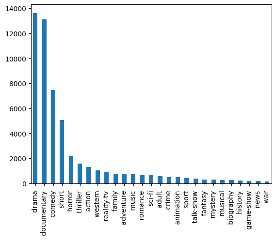

An NLP multi-class classification problem with MANY classes of unequal sizes

## Custom-trained Word2Vec embeddings performed better than pretrained models

Embedding Models Used:

- Glove pre-trained “Wiki-gigaword 300” model (“glove”)
- Spacy pre-trained word2vec model (“SpCyw2v”)
- Word2Vec model trained on my movie description data (“myw2v”)

Baseline Models: Logistic Regression

#### Validation Accuracy

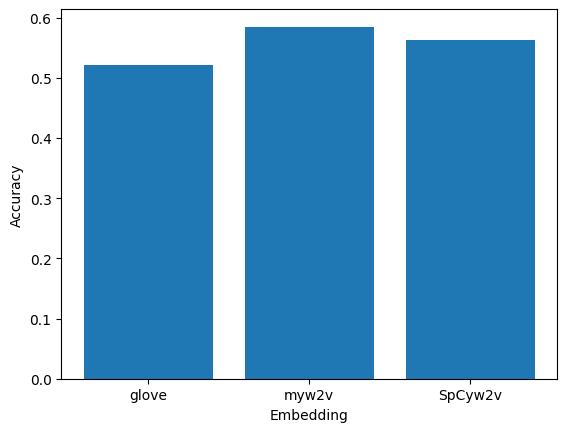

## Over/under fitting depending on model complexity

**Accuracy**

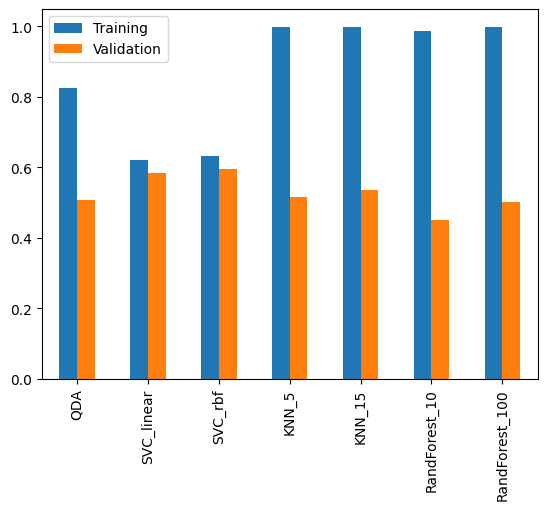

Next, I tried a series of models of increasing complexity

**Note**

**Simpler, linear models underfit the data**

**More complex models overfit**

Without further tweaking the simple models won out on validation set accuraacy for now

## Shortening embedding vector lengths helped some models

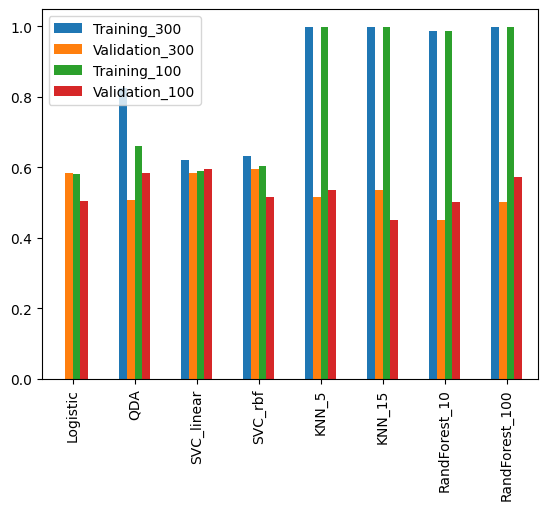

I recreated the embeddings using **vectors of length 100 instead of the original 300**…which seem to help to increase validation accuracy for some models like RandomForest

#### What I’d do next:

Perhaps the overfitting can be overcome by full-scale hyperparameter tuning?

## Thank you!

Big shout out to Anil for being a great small group instructor!